# HW 3: Bikeshare Aggregation

The template uses the following packages.

```r
library(tidyverse)
library(lubridate)
```

# Load Data

We download the data from the [Capital BikeShare program](https://www.capitalbikeshare.com/system-data). Note the license agreement there. We removed some columns of the data that we aren’t using to reduce the size of the dataset you have to download.

The data files are broken up by year. Here we read in the data for both 2011 and 2012, the same two years that you worked with in Homework 1 and 2.

```r
# Read the file, specifying data types for each column.
rides_2011 <- read_csv("data/rides_2011.csv.gz", col_types = cols(
  start_time = col_datetime(),
  duration = col_double(),
  member_type = col_factor()
))
rides_2012 <- read_csv("data/rides_2012.csv.gz", col_types = cols(
  start_time = col_datetime(),
  duration = col_double(),
  member_type = col_factor()
))
```

1. Combine the data from these two years into a single data frame called `rides`. (Hint: `bind_rows`). Report some basic information about its shape.

Each row is a *ride*. For each ride we’re given the start time of the trip, its duration, and “member type”. According to the website:

> Member Type – Indicates whether user was a “registered” member (Annual Member, 30-Day Member or Day Key Member) or a “casual” rider (Single Trip, 24-Hour Pass, 3-Day Pass or 5-Day Pass)
2. What units is `duration` probably measured in? Make a visualization to justify your answer.
3. Make a table that shows how many rides were taken by members and non-members.

```r
rides %>%
  count(member_type)
```

```
## # A tibble: 3 x 2
##   member_type       n
##   <fct>         <int>
## 1 Member      2636066
## 2 Casual       619591
## 3 Unknown          21
```

4. Create a dataframe like the one used in Homework 2 that includes the number of rides in each hour. How many rows does this data frame have? How many *should* it have? (Don’t try to fix this right now.)
- The `floor_date` function can be used to round dates to the nearest hour (see its `unit` parameter).
- You may use `count`, but also try using `summarize(n = n())`

```r
hourly_rides <- rides %>%
  group_by(start_hour = floor_date(start_time, unit = "hours")) %>%
  count()
```

See the `lubridate` [cheat sheet](https://rawgit.com/rstudio/cheatsheets/master/lubridate.pdf) and the [“dates and times” chapter](https://r4ds.had.co.nz/dates-and-times.html) of “R for Data Science”.

1. Break down the result by casual vs registered member.

```r
hourly_rides <- rides %>%
  group_by(hour = floor_date(start_time, unit = "hours"), member_type) %>%
  summarize(rides = n())
```

1. Repeat, aggregating by date instead.
2. Recreate the “Distribution of Rides by Weekday” plot from Homework 2 using this dataset.

Notes:

- You will need the `wday` function (from the `lubridate` package) to get the day of week. Give it `label = TRUE` to get “Sun”, “Mon” instead of numbers.
- Omit the “Unknown” member type.

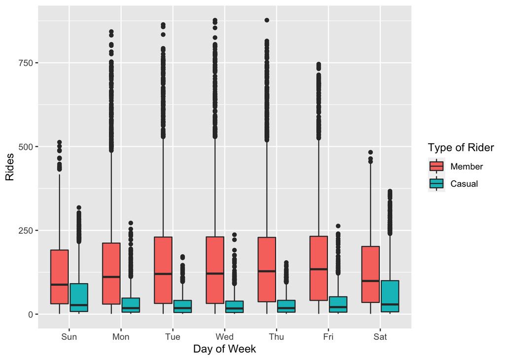

```r
hourly_rides %>%
  filter(member_type != "Unknown") %>%
  ggplot(aes(x = wday(hour, label = TRUE), y = rides, fill = member_type)) +
  geom_boxplot() +
  labs(y = "Rides", x = "Day of Week", fill = "Type of Rider")
```

1. Make a tabular summary of this same dataset: what is the median number of rides taken by each type of rider for each day of the week?
- Bonus: once you get the basic table, try adding as the last step of your pipeline `pivot_wider(names_from = ___, values_from = ___)`, filling in the blanks appropriately.

```r
hourly_rides %>%
  filter(member_type != "Unknown") %>%
  group_by(weekday = wday(hour, label = TRUE), member_type) %>%
  summarize(median_rides = median(rides)) %>%
  pivot_wider(names_from = member_type, values_from = median_rides)
```

```
## # A tibble: 7 x 3
## # Groups:   weekday [7]
##   weekday Member Casual
##   <ord>    <dbl>  <dbl>
## 1 Sun         88     27
## 2 Mon        111     18
## 3 Tue        120     18
## 4 Wed        121     17
## 5 Thu        128     18
## 6 Fri        134     21
## 7 Sat         99     29
```

1. Recreate the “Distribution of Rides by Hour” plot using this dataset.
- Note: the hw2 dataset had marked some holidays as non-working days. For this plot, let’s ignore that and just assume that Saturday and Sunday are the only non-working days.
- You will need these functions:
  - `lubridate::hour`
  - `as_factor`
  - `if_else` or `case_when`.

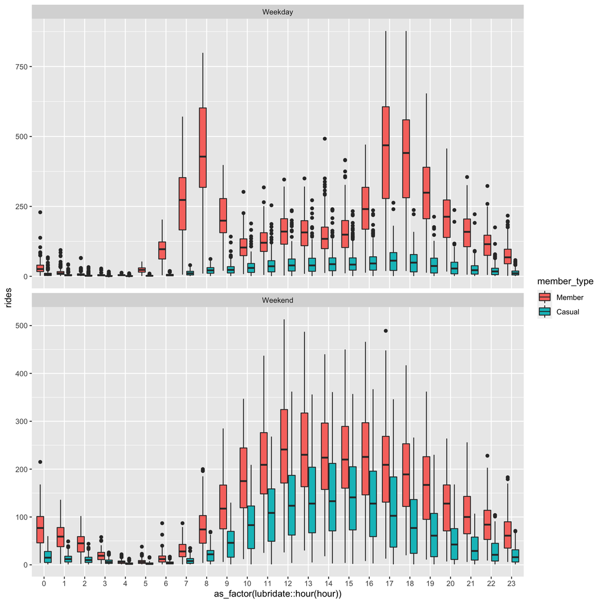

```r
hourly_rides %>%
  filter(member_type != "Unknown") %>%
  mutate(is_weekend = if_else(
    wday(hour, label = TRUE) %in% c("Sat", "Sun"),
    "Weekend", "Weekday")) %>%
  ggplot(aes(x = as_factor(lubridate::hour(hour)), y = rides, fill = member_type)) +
    geom_boxplot() +
    facet_wrap(~ is_weekend, scales = "free_y", nrow = 2)
```

## Appendix: Preprocessing

```r
preprocFile <- function(url, destFile) {
  url %>%
    pin() %>%
    map_dfr( ~ read_csv(
      .,
      col_types = cols_only(
        Duration = col_double(),
        `Start date` = col_datetime(format = ""),
        `Member type` = col_character()
      )
    )) %>%
    select(start_time = `Start date`,
         duration = `Duration`,
         member_type = `Member type`) %>%
    write_csv(destFile)
  system2("gzip", c("-9v", destFile))
}
preprocFile(
  "https://s3.amazonaws.com/capitalbikeshare-data/2011-capitalbikeshare-tripdata.zip",
  "rides_2011.csv"
)
preprocFile(
  "https://s3.amazonaws.com/capitalbikeshare-data/2012-capitalbikeshare-tripdata.zip",
  "rides_2012.csv"
)
```